# DH1 Final Project

I am going to input the full text of the first book I wrote in order to run some tests and do some analysis on it, namely in terms of word frequency and sentiment analysis. My initial (largely failed) attempt at this can be found [here](https://github.com/sem14t/quackmire/blob/master/finalproject). The first step is to load some libraries that might be useful:

```r
library(dplyr)
library(tidytext)
library(gutenbergr)
```

Inputting the text, separated by chapter (code hidden because it’s an incredibly long text): *[code hidden]*

The process of unnesting tokens:

```r
themuse_df <- tibble(line = 1:51, text = themusechs)
themuse_df
themuse_df %>% unnest_tokens(word, text)
themust_unnest <- themuse_df %>% unnest_tokens(word, text)
```

**ELLIE YOU MISSPELLED THE TITLE! Be sure to make note of this moving forward!**

Word frequency tests

```r
themust_unnest %>% count(word, sort = TRUE)
```

| word | n |
| --- | --- |
| the | 2825 |
| and | 2214 |
| her | 2111 |
| to | 1958 |
| a | 1830 |
| she | 1646 |
| elena | 1638 |
| i | 1341 |
| of | 1206 |
| you | 1139 |

[output cut: 990 more lines]

```r
themust_unnest <- themust_unnest %>% anti_join(stop_words)
themust_unnest %>% count(word, sort = TRUE)
```

| word | n |
| --- | --- |
| elena | 1638 |
| edouard | 523 |
| warner | 468 |
| kitty | 313 |
| eyes | 260 |
| antoine | 233 |
| it’s | 186 |
| don’t | 177 |
| hand | 169 |
| head | 164 |

[output cut: 990 more lines]

Elena is the protagnoist of the novel; Edouard, Warner, Kitty, and Antoine are all major characters. However, there are interesting insights to be found from some of the other results. ‘Eyes’ is the 5th most frequent word. Hands, smiles, and time are also used a lot. ‘Don’t’ and ‘take’ are the most frequent verbs. I am not excited that ‘it’s’ is used so much. I will have to think about that during the rewrite. I wanted to visualize this data, so I will attempt to make a graph:

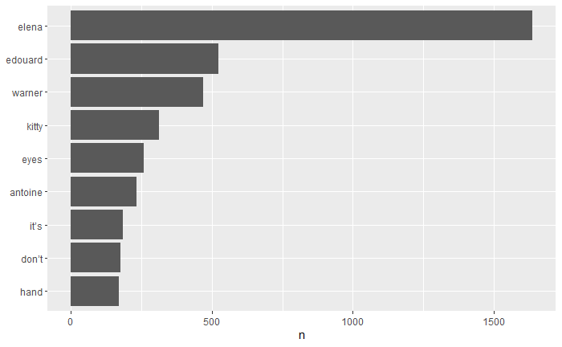

```r
library(ggplot2)
themust_unnest %>%
  count(word, sort = TRUE) %>%
  filter(n > 164) %>%
  mutate(word = reorder(word,n)) %>%
  ggplot(aes(word, n)) +
  geom_col() +
  xlab(NULL) +
  coord_flip()
```

Sentiment analysis with Bing et al.

```r
bing_word_counts <- themust_unnest %>%
  inner_join(get_sentiments("bing")) %>%
  count( word, sentiment, sort = TRUE) %>%
  ungroup()
bing_word_counts
```

| word | sentiment | n |
| --- | --- | --- |
| smiles | positive | 134 |
| love | positive | 87 |
| smile | positive | 79 |
| slowly | negative | 58 |
| beautiful | positive | 49 |
| top | positive | 45 |
| hard | negative | 34 |
| fine | positive | 33 |
| happy | positive | 30 |
| nice | positive | 23 |

[output cut: 990 more lines]

Sentiment analysis with NRC

```r
nrc_word_counts <- themust_unnest %>%
  inner_join(get_sentiments("nrc")) %>%
  count( word, sentiment, sort = TRUE) %>%
  ungroup()
nrc_word_counts
```

| word | sentiment | n |
| --- | --- | --- |
| time | anticipation | 116 |
| love | joy | 87 |
| love | positive | 87 |
| smile | joy | 79 |
| smile | positive | 79 |
| smile | surprise | 79 |
| smile | trust | 79 |
| baby | joy | 64 |
| baby | positive | 64 |
| mouth | surprise | 52 |

[output cut: 990 more lines]

Sentment analysis with AFINN

```r
afinn_word_counts <- themust_unnest %>%
  inner_join(get_sentiments("afinn")) %>%
  count( word, value, sort = TRUE) %>%
  ungroup()
afinn_word_counts
```

| word | value | n |
| --- | --- | --- |
| smiles | 2 | 134 |
| love | 3 | 87 |
| laughs | 1 | 81 |
| smile | 2 | 79 |
| beautiful | 3 | 49 |
| tears | -2 | 45 |
| top | 2 | 45 |
| dear | 2 | 35 |
| hard | -1 | 34 |
| fine | 2 | 33 |

[output cut: 653 more lines]

Graphing bing_word_counts

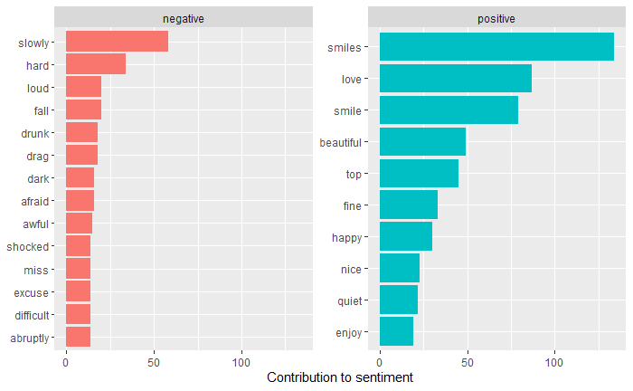

```r
bing_word_counts %>%
  group_by(sentiment) %>%
  top_n(10) %>%
  ungroup() %>%
  mutate(word = reorder(word, n)) %>%
  ggplot(aes(word, n, fill = sentiment)) +
  geom_col(show.legend = FALSE) +
  facet_wrap(~sentiment, scales = "free_y") +
  labs(y = "Contribution to sentiment",
       x = NULL) +
  coord_flip()
```

It seems that, judging by this data alone, the book is much more positive than negative. At least, there are more negative words used, but the positive words used are used more frequently and are considered to be more positive. That’s a bit of a surprise to me, but this analysis is on a word-by-word basis.

```r
install.packages("wordcloud")
```

```
Error in install.packages : Updating loaded packages
```

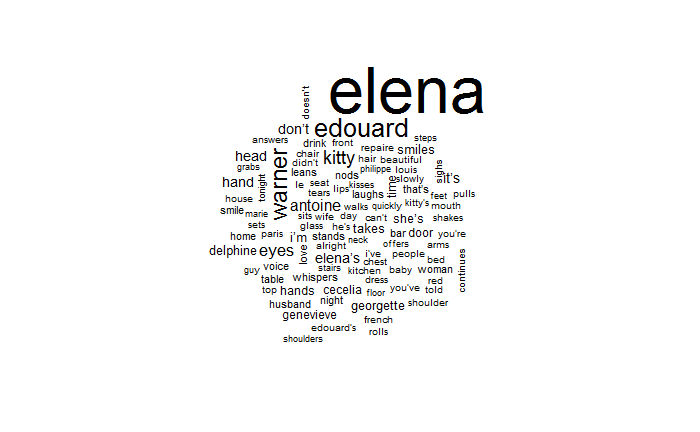

```r
library(wordcloud)
library(reshape2)

themust_unnest %>%
  anti_join(stop_words) %>%
  count(word) %>%
  with(wordcloud(word, n, max.words = 100))
```

Attempting to look at sentiment by chapter

```r
bingnegative <- get_sentiments("bing") %>%
  filter(sentiment == "negative")

wordcounts <- themuse_df %>%
  group_by(line) %>%
  summarize(words = n())

themuse_df %>%
  semi_join(bingnegative) %>%
  group_by(line) %>%
  summarize(negativewords = n()) %>%
  left_join(wordcounts, by = c("chapter")) %>%
  mutate(ratio = negativewords/words) %>%
  filter(line != 0) %>%
  top_n(1) %>%
  ungroup()
```

```
Error: `by` required, because the data sources have no common variables
```

Not sure how to deal with this error message. Tried a lot of different things. It worked with themust_unnest but that was separated by word, not chapter.

Breaking the text down by sentences and graphing by chapter

```r
themusesent <- themuse_df %>% unnest_tokens(sentence, text, token = "sentences")
themusesent
```

| line | sentence |
| --- | --- |
| 1 | the muse by suzanne e. |
| 1 | marvin |
| 3 | dear reader: what follows is a story based on true events and real people who lived long before i ever came along. |
| 3 | everything is fiction here. |
| 3 | a few of the details of this story come from history, but mostly, they are from my imagination. |
| 3 | there are many characters in this book whom you may not like. |
| 3 | in fact, you may find them absolutely wretched. |
| 3 | you may believe they should endure some kind of insufferable torture, at least for a little while. |
| 3 | this is understandable. |
| 3 | however, you must know that i truly and whole-heartedly love many of the characters that populate this story. |

[output cut: 990 more lines]

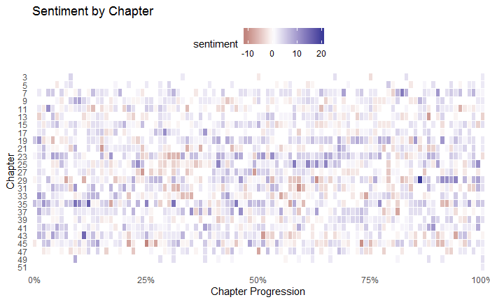

```r
sentbych <- themusesent %>%
  group_by(line) %>%
  mutate(sentence_num = 1:n(),
         index = round(sentence_num / n(), 2)) %>%
  unnest_tokens(word, sentence) %>%
  inner_join(get_sentiments("afinn")) %>%
  group_by(line, index) %>%
  summarise(sentiment = sum(value, na.rm = TRUE)) %>%
  arrange(desc(sentiment))
ggplot(sentbych, aes(index, factor(line, levels = sort(unique(line), decreasing = TRUE)), fill = sentiment)) +
        geom_tile(color = "white") +
        scale_fill_gradient2() +
        scale_x_continuous(labels = scales::percent, expand = c(0, 0)) +
        scale_y_discrete(expand = c(0, 0)) +
        labs(x = "Chapter Progression", y = "Chapter") +
        ggtitle("Sentiment by Chapter") +
        theme_minimal() +
        theme(panel.grid.major = element_blank(),
              panel.grid.minor = element_blank(),
              legend.position = "top")
```

```r
ggsave("test3.png", units="in", width=8, height=7, dpi=300)
```

I really like this graph! It’s interesting to track which chapters start more negatively or positively, where they fall in the middle, and how they end.

Just for fun, I’d like to compare my text to texts from famous authors, like Jane Austen, F. Scott Fitzgerald, the Brontë sisters, and others.

```r
library(gutenbergr)

fscott <- gutenberg_download(c(9830, 4368, 6695, 805))

tidy_fscott <- fscott %>%
  unnest_tokens(word, text) %>%
  anti_join(stop_words)
tidy_fscott %>%
  count(word, sort = TRUE)
```

| word | n |
| --- | --- |
| anthony | 852 |
| amory | 838 |
| eyes | 555 |
| time | 544 |
| gloria | 513 |
| night | 456 |
| day | 424 |
| half | 419 |
| life | 403 |
| people | 354 |

[output cut: 990 more lines]

This comparison to F. Scott Fitzgerald’s corpus available on Project Guternberg is kind of neat. ‘Eyes’ and ‘time’ are two highly-used words in his works, and are also both highly used in my text.

```r
bronte <- gutenberg_download(c(1260, 768, 969, 9182, 767))

tidy_bronte <- bronte %>%
  unnest_tokens(word, text) %>%
  anti_join(stop_words)
tidy_bronte %>%
  count(word, sort = TRUE)
```

| word | n |
| --- | --- |
| time | 1065 |
| miss | 855 |
| day | 827 |
| hand | 768 |
| eyes | 713 |
| night | 647 |
| heart | 638 |
| looked | 601 |
| door | 592 |
| half | 586 |

[output cut: 990 more lines]

‘Time,’ ‘hand,’ ‘eyes,’ and ‘door’ are all relevant words to me here. (Althought, looking at some results, I’ve noticed that ‘eyes’ and ‘hands’ seem to pop up a lot.)

```r
library(janeaustenr)

original_books <- austen_books() %>%
  group_by(book) %>%
  mutate(linenumber = row_number(),
         chapter = cumsum(str_detect(text, regex("^chapter [\\divxlc]",
                                                 ignore_case = TRUE)))) %>%
  ungroup()

original_books
```

| text | book | linenumber | chapter |
| --- | --- | --- | --- |
| SENSE AND SENSIBILITY | Sense & Sensibility | 1 | 0 |
|  | Sense & Sensibility | 2 | 0 |
| by Jane Austen | Sense & Sensibility | 3 | 0 |
|  | Sense & Sensibility | 4 | 0 |
| (1811) | Sense & Sensibility | 5 | 0 |
|  | Sense & Sensibility | 6 | 0 |
|  | Sense & Sensibility | 7 | 0 |
|  | Sense & Sensibility | 8 | 0 |
|  | Sense & Sensibility | 9 | 0 |
| CHAPTER 1 | Sense & Sensibility | 10 | 1 |

[output cut: 990 more lines]

```r
tidy_austen <- original_books %>%
  unnest_tokens(word, text)

tidy_austen <- tidy_austen %>%
  anti_join(stop_words)
tidy_austen %>%
  count(word, sort = TRUE)
```

| word | n |
| --- | --- |
| miss | 1855 |
| time | 1337 |
| fanny | 862 |
| dear | 822 |
| lady | 817 |
| sir | 806 |
| day | 797 |
| emma | 787 |
| sister | 727 |
| house | 699 |

[output cut: 990 more lines]

Again, ‘time’ appears. Austen’s top words are more location- and character-based.

Just for fun, I thought I would use [this](http://varianceexplained.org/r/tidytext-gender-plots/) tutorial to look into how I am representing gender in my text.

```r
bigrams <- themuse_df %>%
  unnest_tokens(bigram, text, token = "ngrams", n = 2, collapse = FALSE)

bigrams_separated <- bigrams %>%
  separate(bigram, c("word1", "word2"), sep = " ")

he_she_words <- bigrams_separated %>%
  filter(word1 %in% c("he", "she"))

he_she_counts <- he_she_words %>%
  count(word1, word2) %>%
  spread(word1, n, fill = 0) %>%
  mutate(total = he + she,
         he = (he + 1) / sum(he + 1),
         she = (she + 1) / sum(she + 1),
         log_ratio = log2(she / he),
         abs_ratio = abs(log_ratio)) %>%
  arrange(desc(log_ratio))

he_she_counts
```

| word2 | he | she | total | log_ratio | abs_ratio |
| --- | --- | --- | --- | --- | --- |
| can’t | 0.000635324 | 0.0071428571 | 15 | 3.49093681 | 3.49093681 |
| can | 0.002541296 | 0.0142857143 | 34 | 2.49093681 | 2.49093681 |
| trails | 0.000635324 | 0.0035714286 | 7 | 2.49093681 | 2.49093681 |
| drops | 0.000635324 | 0.0031250000 | 6 | 2.29829173 | 2.29829173 |
| gasps | 0.000635324 | 0.0031250000 | 6 | 2.29829173 | 2.29829173 |
| had | 0.000635324 | 0.0031250000 | 6 | 2.29829173 | 2.29829173 |
| finds | 0.001270648 | 0.0058035714 | 13 | 2.19137653 | 2.19137653 |
| brings | 0.000635324 | 0.0026785714 | 5 | 2.07589931 | 2.07589931 |
| tells | 0.000635324 | 0.0026785714 | 5 | 2.07589931 | 2.07589931 |
| wonders | 0.000635324 | 0.0026785714 | 5 | 2.07589931 | 2.07589931 |

[output cut: 584 more lines]

Visualizing that chart:

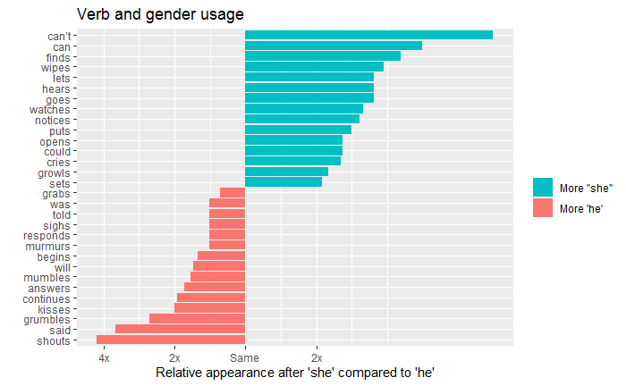

```r
library(ggplot2)
library(readr)
library(scales)

he_she_counts %>%
  filter(!word2 %in% c("himself", "herself"),
         total>= 9) %>%
  group_by(direction = ifelse(log_ratio > 0, 'More "she"', "More 'he'")) %>%
  top_n(15, abs_ratio) %>%
  ungroup() %>%
  mutate(word2 = reorder(word2, log_ratio)) %>%
  ggplot(aes(word2, log_ratio, fill = direction)) +
  geom_col() +
  coord_flip() +
  labs(x = "",
       y = "Relative appearance after 'she' compared to 'he'",
       fill = "",
       title = "Verb and gender usage") +
  scale_y_continuous(labels = c("4x", "2x", "Same", "2x"),
                     breaks = seq(-2, 1)) +
  guides(fill = guide_legend(reverse = TRUE))

ggsave("verbusage.png", units="in", width=8, height=7, dpi=300)
```

There’s a ton of interesting stuff here. I am ashamed to find that the verb most often used with ‘she’ is ‘can’t’–this is only made better by the fact that the second-most used verb is ‘can.’ Women cry a lot more than men in this text (though I often used ‘cries’ as in ‘says with emotion’ and not ‘cries actual tears’). I am also painting a negative portrayal of men, as the most common verb associated with ‘he’ is ‘shouts.’ ‘He’ seems to be followed by a lot of speaking verbs (‘said,’ ‘grumbles,’ ‘answers,’ ‘mumbles,’ etc.). It seems like–according to this data alone–I am portraying women as more passive (shown by the frequence of words like ‘lets,’ ‘hears,’ and ‘watches’) and men as more active, talkative, and angry. This is definitely something I want to consider (and change) during my rewrites.

Some more quick work with bigrams:

```r
musebigrams <- themuse_df %>%
  unnest_tokens(bigram, text, token = "ngrams", n = 2)

musebigrams %>% count(bigram, sort = TRUE)
```

| bigram | n |
| --- | --- |
| of the | 242 |
| on the | 208 |
| in the | 204 |
| to the | 197 |
| with a | 158 |
| at the | 143 |
| she says | 130 |
| of her | 128 |
| a few | 120 |
| for a | 114 |

[output cut: 990 more lines]

```r
musebisep <- musebigrams %>%
  separate(bigram, c("word1", "word2"), sep = " ")

bigrams_filtered <- musebisep %>%
  filter(!word1 %in% stop_words$word) %>%
  filter(!word2 %in% stop_words$word)

bigram_counts <- bigrams_filtered %>%
  count(word1, word2, sort = TRUE)

bigram_counts %>%
  filter(!word1 %in% "elena")
```

| word1 | word2 | n |
| --- | --- | --- |
| le | repaire | 55 |
| NA | NA | 25 |
| edouard | elena | 16 |
| elena’s | eyes | 16 |
| leans | forward | 15 |
| madame | pavard | 14 |
| ms | wise | 14 |
| front | door | 13 |
| deep | breath | 12 |
| mademoiselle | delphine | 12 |

[output cut: 990 more lines]

These bigrams were interesting but were dominated by Elena, the main character, so I filtered her name out of the first word. ‘Le repaire’ is the name of a major location, so that makes sense that it’s mentioned most frequently as a bigram. A lot of the bigrams are characters’ names and/or titles, like Madame Pavard and Ms Wise. The bigrams that most interest me here are ‘Elena’s eyes,’ ‘Warner sighs,’ ‘I’m afraid,’ and ‘God Elena,’ which is a kind of surprising one.

Lastly, I would like to look at some bigrams specific to characters and other words.

```r
bigram_counts %>% filter(word1 == "kitty")
```

| word1 | word2 | n |
| --- | --- | --- |
| kitty | smiles | 9 |
| kitty | kitty | 7 |
| kitty | laughs | 7 |
| kitty | elena | 6 |
| kitty | sighs | 6 |
| kitty | nods | 5 |
| kitty | breathes | 3 |
| kitty | offers | 3 |
| kitty | pours | 3 |
| kitty | answers | 2 |

[output cut: 86 more lines]

```r
bigram_counts %>% filter(word1 == "eyes")
```

| word1 | word2 | n |
| --- | --- | --- |
| eyes | widen | 10 |
| eyes | watering | 7 |
| eyes | meet | 6 |
| eyes | wide | 5 |
| eyes | dart | 4 |
| eyes | elena | 4 |
| eyes | darting | 3 |
| eyes | edouard | 3 |
| eyes | light | 3 |
| eyes | closed | 2 |

[output cut: 54 more lines]

```r
bigram_counts %>% filter(word1 == "edouard")
```

| word1 | word2 | n |
| --- | --- | --- |
| edouard | elena | 16 |
| edouard | nods | 9 |
| edouard | takes | 9 |
| edouard | smiles | 8 |
| edouard | returns | 6 |
| edouard | shakes | 6 |
| edouard | sighs | 6 |
| edouard | stands | 6 |
| edouard | rolls | 5 |
| edouard | sets | 5 |

[output cut: 147 more lines]

```r
bigram_counts %>% filter(word1 == "warner")
```

| word1 | word2 | n |
| --- | --- | --- |
| warner | sighs | 11 |
| warner | smiles | 10 |
| warner | stands | 7 |
| warner | answers | 6 |
| warner | elena | 6 |
| warner | offers | 6 |
| warner | explains | 5 |
| warner | laughs | 5 |
| warner | pauses | 5 |
| warner | warner | 5 |

[output cut: 138 more lines]

```r
bigram_counts %>% filter(word1 == "genevieve")
```

| word1 | word2 | n |
| --- | --- | --- |
| genevieve | elena | 7 |
| genevieve | nods | 5 |
| genevieve | smiles | 3 |
| genevieve | continues | 2 |
| genevieve | cries | 2 |
| genevieve | genevieve | 2 |
| genevieve | stands | 2 |
| genevieve | weeps | 2 |
| genevieve | adds | 1 |
| genevieve | answers | 1 |

[output cut: 37 more lines]

```r
bigram_counts %>% filter(word1 == "delphine")
```

| word1 | word2 | n |
| --- | --- | --- |
| delphine | smiles | 6 |
| delphine | takes | 4 |
| delphine | stands | 3 |
| delphine | kisses | 2 |
| delphine | laughs | 2 |
| delphine | leans | 2 |
| delphine | nods | 2 |
| delphine | she’s | 2 |
| delphine | sits | 2 |
| delphine | slides | 2 |

[output cut: 53 more lines]

```r
bigram_counts %>% filter(word1 == "antoine")
```

| word1 | word2 | n |
| --- | --- | --- |
| antoine | answers | 5 |
| antoine | takes | 5 |
| antoine | smiles | 4 |
| antoine | stands | 4 |
| antoine | elena | 3 |
| antoine | leans | 3 |
| antoine | sighs | 3 |
| antoine | chuckles | 2 |
| antoine | follow | 2 |
| antoine | growls | 2 |

[output cut: 70 more lines]

In conclusion, I have learned a lot of things about my little book. ‘Elena’ is used a lot–perhaps too much. The analysis on gender was particularly enlightening. I have a lot of things to consider as I move into the rewrite process next semester, and I hope that the next time I run these tests, I am a lot happier with the results.